# Week 8: Mixture Models

PS 818 - Data Analysis with Statistical Models

Anton Strezhnev

strezhnev@wisc.edu

University of Wisconsin-Madison

October 26, 2026

## Mixture Models

## Previously

- **Multilevel/Hierarchical models**
  - Impose **structure** on parameters by way of prior distributions
  - Information from **grouping** (partial pooling/“random effects”)
  - Strength of the prior determines the degree of pooling
- **Model checking**
  - Posterior predictive checks: can the model reproduce features of the data?
  - Comparing models: information criteria and cross-validation
- **MrP**: multilevel regression + post-stratification to adjust non-representative surveys

## This week

- **“Exploratory” modeling**
  - Unsupervised “clustering” algorithms
  - K-means clustering
  - Finite mixture models
  - Obtaining MLEs or posterior modes via **Expectation-Maximization**
- **Running example**: Policy attitudes in the 2023 CES
  - Are there distinct “types” of voters in terms of their policy attitudes?
  - Next week we’ll ask the same question with a **continuous** latent variable (item response theory)

## Finite Mixture Models

- In conventional **regression** models, we assume a known distribution for the outcome given a set of covariates
  - The covariates could be something like a discrete “group” label (e.g. $X_i = x$)
- In this setting, conditional on $X_i$, we would model each $Y_i$ with a known distribution (e.g. Normal)

  $$Y_i | X_i = x \sim \text{Normal}(\mu_{x}, \sigma^2_{x})$$

  $\mu_{x}$ and $\sigma^2_{x}$ are the mean and variance parameters associated with the group $X_i = x$.
- Now imagine that the group indicators are **not observed** but instead are **latent variables**
  - We can do inference on these conditional on the observed data and the model.

## Finite Mixture Models

- In a **finite** mixture model, we assume that the outcome distribution for each observation $i$ is governed by some discrete latent indicator $z_i \in \{1, 2, \dotsc, K\}$
  - $z_1, z_2, \dotsc, z_N$ are i.i.d. $\sim \text{Categorical}(\pi)$
- Conditional on the latent variable $z_i = k$, the outcome distribution is known.
  - For a continuous outcome, a **gaussian** mixture: $Y_i | z_i = k \sim \text{Normal}(\mu_{k}, \sigma^2_{k})$
  - For a binary outcome, a **Bernoulli** mixture: $Y_i | z_i = k \sim \text{Bernoulli}(\beta_{k})$
- But unconditionally, $Y_i$ has a **mixture** distribution: its density is a weighted average of the component densities. In the gaussian case:

  $$Y_i \sim \sum_{k=1}^K \pi_k \times \text{Normal}(\mu_{k}, \sigma^2_{k})$$

  where $\pi_k = Pr(z_i = k)$
- Our goal is to estimate the parameters of each component and the mixing proportions $\pi$ using likelihood inference.
  - Put priors on the component parameters and $\pi$ to make it fully Bayesian.

## Application: Policy attitudes

- The **organization** of voters’ policy views is at the heart of political science.
  - Are voters’ attitudes well-summarized by a single dimension (“left” vs. “right”)?
  - Or are many voters cross-pressured?
  - Is there any structure to voters’ attitudes (Converse 1964)?
- Recent methodological debate in the *APSR*
  - Fowler et al. (2023): most moderates are genuine centrists on a single dimension - few “Conversian” or Inattentive voters.
  - Broockman and Lauderdale (2025): this is a modelling artifact - moderates are actually much less constrained!
  - These next two weeks are about the statistical model(s) at the core of this debate.
- Surveys ask respondents batteries of **yes/no** policy questions
  - Can we recover groups of respondents with similar response patterns without telling the model anything about party or ideology?

## Data: CES 2023

- The 2023 **Cooperative Election Study** (Schaffner et al. 2024): the full public release, as downloaded from Dataverse

```r
library(haven)
ces_raw <- read_dta("data/CCES23_Common_OUTPUT.dta.gz") # haven reads the compressed Stata file directly
dim(ces_raw)
```

```
[1] 24500   320
```

- Stata files carry **value labels**: each policy question is coded `1` = Support, `2` = Oppose, `8` = skipped, `9` = not asked

```r
count(ces_raw, CC23_324c) # "Make abortions illegal in all circumstances"
```

```
# A tibble: 3 × 2
  CC23_324c       n
  <dbl+lbl>   <int>
1 1 [Support]  4539
2 2 [Oppose]  19955
3 8 [skipped]     6
```

- The questionnaire (`data/CES 2023 CC Questionnaire.pdf`) has the full wording of every item

## Data: CES 2023

- 24 “support/oppose” policy questions on guns and policing, immigration, abortion, the environment, and social welfare

```r
items <- c(ban_assault_rifles = "CC23_321a", concealed_carry = "CC23_321b", background_checks = "CC23_321c",
           more_police = "CC23_321d", fewer_police = "CC23_321e", legal_status = "CC23_323a",
           border_patrols = "CC23_323b", border_wall = "CC23_323c", dreamers = "CC23_323d",
           abortion_choice = "CC23_324a", abortion_exceptions = "CC23_324b", abortion_ban = "CC23_324c",
           abortion_expand = "CC23_324d", epa_co2 = "CC23_326a", renewable_mandate = "CC23_326b",
           epa_enforcement = "CC23_326c", more_fossil_fuels = "CC23_326d", halt_leases = "CC23_326e",
           relax_zoning = "CC23_328a", housing_credits = "CC23_328b", medicaid_work_req = "CC23_328c",
           repeal_aca = "CC23_328d", expand_medicaid = "CC23_328e", forgive_loans = "CC23_328f")
ces <- ces_raw %>%
  transmute(caseid, commonweight, pid3 = as.character(as_factor(pid3)), ideo5 = as.character(as_factor(ideo5)),
            across(all_of(items), ~ case_when(.x == 1 ~ 1, .x == 2 ~ 0))) %>% # skipped/not asked become NA
  drop_na(all_of(names(items)))
Y <- as.matrix(select(ces, all_of(names(items)))) # 1 = Support, 0 = Oppose
```

- 24,453 of the 24,500 respondents answered all 24 questions

## Data: CES 2023

| Item | Support | Item | Support |
| --- | --- | --- | --- |
| Ban assault rifles | 63% | Expand abortion access | 59% |
| Easier concealed-carry permits | 40% | EPA regulates CO2 | 64% |
| Background checks on all gun sales | 91% | Renewable fuel mandate | 57% |
| 10% more police | 57% | Stronger EPA enforcement | 61% |
| 10% fewer police | 31% | More fossil fuel production | 58% |
| Legal status for undocumented workers | 64% | Halt new oil and gas leases | 47% |
| More border patrols | 72% | Relax zoning | 49% |
| Build a border wall | 52% | Tax credits for low-income housing | 73% |
| Citizenship path for Dreamers | 71% | Medicaid work requirements | 56% |
| Always allow abortion | 62% | Repeal the ACA | 44% |
| Abortion only for rape, incest, life | 52% | Expand Medicaid | 80% |
| Make abortion illegal | 19% | Forgive student loans | 59% |

## Clustering

- Each respondent is a vector of 24 ones and zeroes.

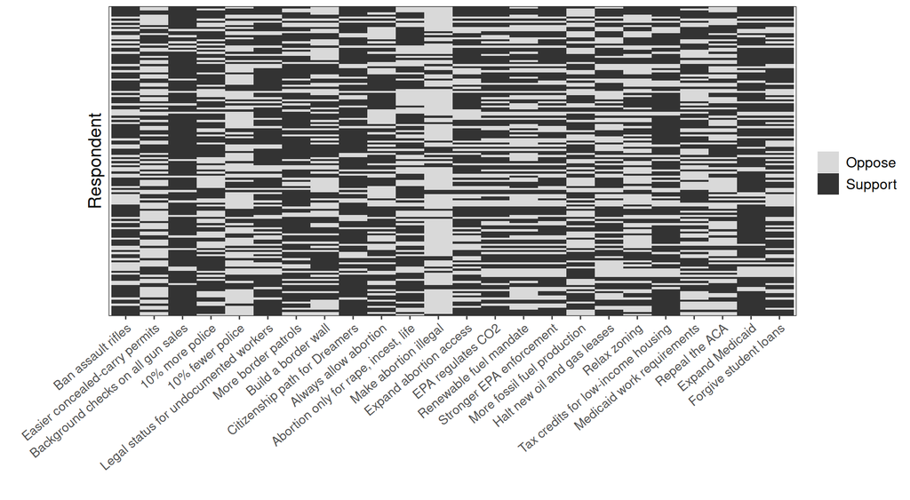

## K-means

- A simple algorithm for finding clusters that has no underlying probabilistic model is the **K-means algorithm**
  - Straightforward to implement and still surprisingly popular and effective for a “first cut” at the data.
- **K-means algorithm**
  1. Initialize $K$ distinct clusters by randomly assigning points to one of the $K$ groups
  2. Calculate $\mu_k$ as the mean of $Y_i$ in observations in cluster $k$.
  3. Reassign each point to the cluster $k$ that has the smallest distance between $Y_i$ and $\mu_k$.
  4. Repeat 2-3 until no points change their assignments.
- With binary responses, $\mu_k$ is the vector of **proportions supporting** each policy among respondents in cluster $k$

## K-means example

- R’s `kmeans()` implements the algorithm; `nstart` re-runs it from multiple random starts and keeps the result with smallest within-cluster sum of squares.

```r
set.seed(53703)
km2 <- kmeans(Y, centers = 2, nstart = 10)
km2$size
```

```
[1]  8803 15650
```

- Sorting our 150 respondents by their assigned cluster

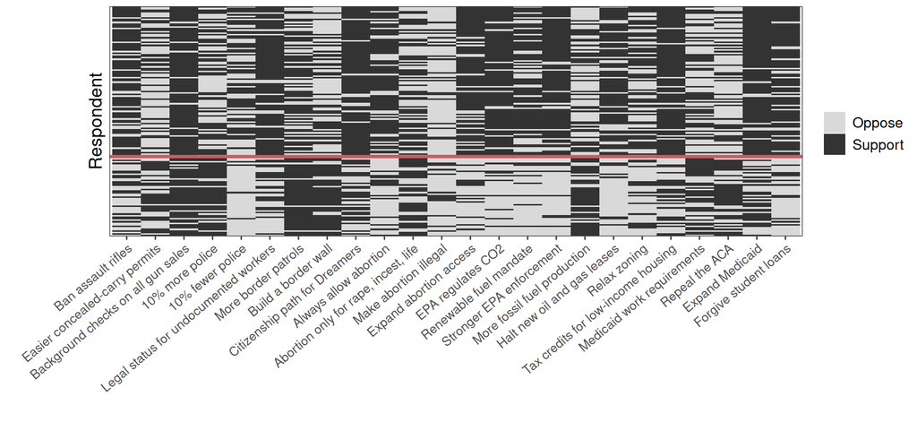

## K-means example

- The cluster centroids $\mu_k$: share of each cluster supporting each policy

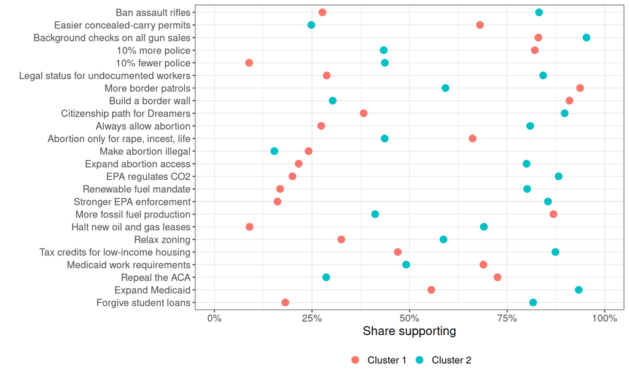

## K-means example

- How do the clusters compare to respondents’ **party identification**?

```r
table(cluster = km2$cluster, party = ces$pid3)
```

```
       party
cluster Democrat Independent Not sure Other Republican
      1      569        2605      348   450       4831
      2     8257        3812     1164   467       1950
```

- The clusters themselves don’t have any underlying interpretation or meaning
  - We **assign** the interpretation through inspection.

## K-means

- Advantages
  - Easy to implement, fast updates, and quick convergence.
- Disadvantages
  - Multimodality (we can’t really solve this one!)
  - Choice of distance metric matters (e.g. should we standardize the items somehow?)
  - Euclidean distance is an awkward fit for binary/discrete outcomes
- With conventional K-means, we have no underlying probability model – each unit is assigned to a single cluster.
  - Sometimes called **“hard”** K-means.
- We can instead implement an approach sometimes referred to as a “soft” K-means algorithm
  - Our target of inference is the **probability** that a unit belongs to each cluster.

## Bernoulli Mixture Models

- We observe $N$ respondents each giving binary responses to $J$ questions. $Y_i$ is the vector of responses for unit $i$ with components $Y_{ij}$.
- Assume **latent variables** $z = \{z_1, z_2, \dotsc, z_N\}$

  $$z_i \underset{\text{i.i.d.}}{\sim} \text{Categorical}(\pi)$$
- Conditional on $z_i = k$, each response is **independently** Bernoulli with a cluster-and-question-specific probability $\beta_{kj}$

  $$Y_{ij} | z_i = k \sim \text{Bernoulli}(\beta_{kj})$$
- Our targets of inference are the $K \times J$ matrix of response probabilities $\beta$ and the cluster prevalences $\pi$
  - And conditional on these estimates, we can obtain the cluster probabilities $Pr(z_i = k | Y_i)$

## Local independence

- The key assumption: **conditional** on cluster membership, a respondent’s answers are independent

  $$f(Y_i | z_i = k) = \prod_{j=1}^J \beta_{kj}^{Y_{ij}}(1 - \beta_{kj})^{1 - Y_{ij}}$$
- Answers are certainly **not** independent marginally
  - Supporting an assault rifle ban is strongly correlated with supporting background checks
- The mixture model says **all** of that correlation comes from respondents belonging to different clusters
  - Within a cluster, knowing someone supports a ban tells you nothing about how they’ll answer on background checks
  - This is a strong assumption!

## Expectation-Maximization

- Let’s write down the marginal likelihood, summing out the latent variables:

  $$\mathcal{L}(\beta, \pi; \mathbf{Y}) = \prod_{i=1}^N \sum_{k=1}^K f(Y_i| \beta_{k}, z_i = k) \times p(z_i = k | \pi)$$
- This is a tricky likelihood to maximize - if we take the log, we get a log of a sum (which doesn’t simplify as neatly as a log of a product)

  $$\ell(\beta, \pi ; \mathbf{Y}) = \sum_{i=1}^N \log\bigg(\sum_{k=1}^K \pi_k \prod_{j=1}^J \beta_{kj}^{Y_{ij}}(1 - \beta_{kj})^{1 - Y_{ij}} \bigg)$$
- Suppose we knew the $z_i$ as well (they were like “data”), then the “complete” log-likelihood would be easier to maximize!

  $$\ell(\beta, \pi ; \mathbf{Y}, \mathbf{Z}) = \sum_{i=1}^N \sum_{k=1}^K I(z_i = k) \bigg[\log \pi_k + \sum_{j=1}^J \Big(Y_{ij} \log \beta_{kj} + (1 - Y_{ij}) \log (1 - \beta_{kj})\Big)\bigg]$$

## Expectation-Maximization

- The **Expectation-Maximization** algorithm (Dempster et al. 1977) is an iterative method for obtaining a maximum likelihood estimate (or maximum a posteriori (MAP) in a Bayesian setting) when the likelihood consists of a sum/integral over the distribution of some **latent variables**
  - It uses the idea of iteratively optimizing a **lower bound** on the likelihood until convergence is reached.
  - The key trick is **Jensen’s inequality**. For a **concave** function like the logarithm:

  $$\log(E[X]) \ge E[\log(X)]$$
- Consider the general setting where we have a parameter $\theta$, data $\mathbf{X}$ and discrete latent variables $\mathbf{Z}$
- We want to optimize the log-likelihood:

  $$\ell(\theta; \mathbf{X}) = \log \sum_{\mathbf{Z}} f(\mathbf{X}, \mathbf{Z} | \theta) = \log \sum_{\mathbf{Z}} f(\mathbf{X} | \mathbf{Z}, \theta) p(\mathbf{Z} | \theta)$$

## Expectation-Maximization

- Instead of optimizing the log-likelihood directly, we’ll optimize its **lower bound**. Define some arbitrary distribution on the latent variables $q(\mathbf{Z})$.
- Multiply by 1:

  $$\ell(\theta; \mathbf{X}) = \log \sum_{\mathbf{Z}} f(\mathbf{X} | \mathbf{Z}, \theta) p(\mathbf{Z} | \theta) \frac{q(\mathbf{Z})}{q(\mathbf{Z})}$$
- Rearranging terms, we can see that this can be written as an expectation over the distribution $q$

  $$\ell(\theta; \mathbf{X}) = \log E_{q} \bigg[\frac{ f(\mathbf{X} | \mathbf{Z}, \theta) p(\mathbf{Z} | \theta)}{q(\mathbf{Z})}\bigg]$$
- By **Jensen’s inequality**, we have a lower bound

  $$\ell(\theta; \mathbf{X}) \ge E_{q} \bigg[ \log \bigg(\frac{ f(\mathbf{X} | \mathbf{Z}, \theta) p(\mathbf{Z} | \theta)}{q(\mathbf{Z})}\bigg)\bigg]$$

## Expectation-Maximization

- And by properties of logs, our lower-bound is:

  $$\ell(\theta; \mathbf{X}) \ge E_{q}[\log f(\mathbf{X}|\mathbf{Z}, \theta)] + E_{q}[\log p(\mathbf{Z}| \theta)] - E_{q}[\log q(\mathbf{Z})]$$
- We can optimize this **iteratively** by switching between finding an optimal distribution $q^{(t+1)}$ given parameter values $\theta^{(t)}$ and finding parameter values $\theta^{(t+1)}$ given an existing choice of $q^{(t+1)}$.
  1. **Expectation** step: Find $q^{(t+1)}$ (what distribution are we taking the expectation over)
  2. **Maximization** step: Find $\theta^{(t+1)}$ (given our $q$ distribution, what is the value of the parameter values that maximizes the lower bound).

## E-step

- Can we find a closed-form “optimal” solution for our update $q^{(t+1)}$ given $\theta^{(t)}$?
  - Yes, find the $q$ that makes the inequality an equality!

  $$\ell(\theta^{(t)}; \mathbf{X}) \ge E_{q} \bigg[ \log \bigg(\frac{ f(\mathbf{X} | \mathbf{Z}, \theta^{(t)}) p(\mathbf{Z} | \theta^{(t)})}{q(\mathbf{Z})}\bigg)\bigg]$$

  $$\ell(\theta^{(t)}; \mathbf{X}) \ge \sum_{\mathbf{Z}}\log \bigg(\frac{ f(\mathbf{X}, \mathbf{Z} | \theta^{(t)}) }{q(\mathbf{Z})}\bigg) q(\mathbf{Z})$$

## E-step

- Let’s try to get the $\mathbf{Z}$ out of the log. Start by factoring the joint distribution in the numerator conditioning on $\mathbf{X}$ instead of $\mathbf{Z}$

  $$\ell(\theta^{(t)}; \mathbf{X}) \ge \sum_{\mathbf{Z}}\log \bigg(\frac{ f(\mathbf{Z} | \mathbf{X}, \theta^{(t)}) p(\mathbf{X} | \theta^{(t)})}{q(\mathbf{Z})}\bigg) q(\mathbf{Z})$$
- Now we can see the optimal choice for $q^{(t+1)}$ revealed to us. Suppose we plug in $q = f(\mathbf{Z} | \mathbf{X}, \theta^{(t)})$, the conditional distribution of $\mathbf{Z}$ given $\mathbf{X}$ and $\theta^{(t)}$:

  $$\ell(\theta^{(t)}; \mathbf{X}) \ge \sum_{\mathbf{Z}}\log p(\mathbf{X} | \theta^{(t)}) \times f(\mathbf{Z} | \mathbf{X}, \theta^{(t)})$$
- The logged term no longer depends on $\mathbf{Z}$, so pull it out of the sum

  $$\ell(\theta^{(t)}; \mathbf{X}) \ge \log p(\mathbf{X} | \theta^{(t)}) \times \sum_{\mathbf{Z}} f(\mathbf{Z} | \mathbf{X}, \theta^{(t)})$$

## E-step

- The sum is equal to $1$ (sum over a PMF/PDF) and we’re left with the definition of the marginal log-likelihood, so this expression holds with *equality*

  $$\ell(\theta^{(t)}; \mathbf{X}) = \log p(\mathbf{X} | \theta^{(t)})$$
- So our choice of distribution over which to take the expectation of the joint likelihood is $q^{(t+1)} = f(\mathbf{Z} | \mathbf{X}, \theta^{(t)})$

## M-step

- Let’s go back to our lower bound - for a given value of $q^{(t+1)}$, we want to find the $\theta^{(t+1)}$ that maximize the “complete data” log-likelihood

  $$\ell(\theta; \mathbf{X}) \ge E_{q^{(t+1)}}[\log f(\mathbf{X}|\mathbf{Z}, \theta)] + E_{q^{(t+1)}}[\log p(\mathbf{Z}| \theta)] - E_{q^{(t+1)}}[\log q^{(t+1)}(\mathbf{Z})]$$
- Since the third term doesn’t depend on $\theta$, we only need to worry about the first two.
  - This expectation is sometimes called the “Q-Function” $Q(\theta | \theta^{(t)})$ or the expected “complete data” log-likelihood

  $$Q(\theta | \theta^{(t)}) = E_{\mathbf{Z}|\mathbf{X}, \theta^{(t)}}[\log f(\mathbf{X}, \mathbf{Z}| \theta)]$$
- The M-step sets $\theta^{(t+1)}$ to the value of $\theta$ that maximizes this Q-function

  $$\theta^{(t+1)} = \argmax_{\theta} Q(\theta | \theta^{(t)})$$
- Each E-step makes the bound touch the log-likelihood at $\theta^{(t)}$, and each M-step pushes the bound up, so the log-likelihood **never decreases** from one iteration to the next

## Deriving EM for the Bernoulli mixture

- For current values $\beta^{(t)}$, $\pi^{(t)}$, let’s derive the conditional distribution $z_i | Y_i, \beta^{(t)}, \pi^{(t)}$ using Bayes’ rule

  $$p(z_i = k | Y_i, \beta^{(t)}, \pi^{(t)}) = \frac{p(z_i = k | \pi^{(t)}) f(Y_i | \beta^{(t)}, z_i = k)}{f(Y_i | \beta^{(t)}, \pi^{(t)})}$$
- Given $z_i = k$, the responses are independent Bernoulli draws. And the denominator is just the sum of the numerator over $k$

  $$\gamma_{ik} = p(z_i = k | Y_i, \beta^{(t)}, \pi^{(t)}) = \frac{\overbrace{\pi_k^{(t)}}^{\text{prior}} \overbrace{\prod_{j=1}^J \big(\beta_{kj}^{(t)}\big)^{Y_{ij}}\big(1 - \beta_{kj}^{(t)}\big)^{1 - Y_{ij}}}^{\text{likelihood of } Y_i \text{ under cluster } k}}{\underbrace{\sum_{l=1}^K \pi_l^{(t)} \prod_{j=1}^J \big(\beta_{lj}^{(t)}\big)^{Y_{ij}}\big(1 - \beta_{lj}^{(t)}\big)^{1 - Y_{ij}}}_{\text{prior} \times \text{likelihood, summed over all clusters}}}$$
- These weights, $\gamma_{ik}$ are sometimes called the “responsibility” parameters as they denote the extent to which each cluster is “responsible” for an observation.

## Deriving EM for the Bernoulli mixture

- Recall the “complete” log-likelihood

  $$\ell(\beta, \pi ; \mathbf{Y}, \mathbf{Z}) = \sum_{i=1}^N \sum_{k=1}^K I(z_i = k) \bigg[\log \pi_k + \sum_{j=1}^J \Big(Y_{ij} \log \beta_{kj} + (1 - Y_{ij}) \log (1 - \beta_{kj})\Big)\bigg]$$
- Now, taking the expectation over $z_i$, the only component that is not a constant is $I(z_i = k)$ and $E[I(z_i = k)] = p(z_i = k)$ (fundamental bridge).
  - And we got that (conditional) expectation in the previous slide: $\gamma_{ik}$
- So our Q function is

  $$Q(\beta, \pi | \beta^{(t)}, \pi^{(t)}) = \sum_{i=1}^N \sum_{k=1}^K \gamma_{ik} \bigg[\log \pi_k + \sum_{j=1}^J \Big(Y_{ij} \log \beta_{kj} + (1 - Y_{ij}) \log (1 - \beta_{kj})\Big)\bigg]$$
- $\beta^{(t)}$ and $\pi^{(t)}$ only enter through the responsibilities $\gamma_{ik}$

## Deriving EM for the Bernoulli mixture

- Closed form solutions for the M-step: each $\beta_{kj}$ is a **weighted** Bernoulli MLE, and $\pi$ comes from maximizing $\sum_k n_k \log \pi_k$ subject to $\sum_k \pi_k = 1$

  $$n_k = \sum_{i=1}^N \gamma_{ik}$$
  $$\pi_k = \frac{n_k}{N}$$
  $$\beta_{kj} = \frac{1}{n_k}\sum_{i=1}^N \gamma_{ik} Y_{ij}$$
- Compare to K-means: $\beta_{kj}$ is the share supporting policy $j$ in cluster $k$, but every respondent counts toward every cluster in proportion to $\gamma_{ik}$
  - K-means is the special case where each $\gamma_{ik}$ is forced to be $0$ or $1$

## MAP estimation with EM

- EM works just as well for finding the **posterior mode** – add the log prior to the Q-function

  $$Q(\beta, \pi | \beta^{(t)}, \pi^{(t)}) + \log p(\beta) + \log p(\pi)$$
- With conjugate priors, the M-step stays in closed form
  - $\beta_{kj} \sim \text{Beta}(a, b)$ and $\pi \sim \text{Dirichlet}(\alpha, \dotsc, \alpha)$

  $$\beta_{kj} = \frac{\sum_{i=1}^N \gamma_{ik} Y_{ij} + a - 1}{n_k + a + b - 2} \qquad \pi_k = \frac{n_k + \alpha - 1}{N + K(\alpha - 1)}$$
- The prior acts like **pseudo-observations** added to each cluster
  - Keeps $\beta_{kj}$ away from exactly $0$ or $1$ (where the log-likelihood blows up) when a cluster is small
- Below we use $a = b = 2$ and a flat prior on $\pi$ ($\alpha = 1$)
  - With 24,453 respondents, this has little effect on the estimates, but it keeps EM from crashing when a cluster has no units.

## Implementing EM

- For the complete data log-likelihood, entry $(i, k)$ is $\log \pi_k + \sum_j Y_{ij}\log \beta_{kj} + (1 - Y_{ij})\log(1 - \beta_{kj})$

```r
bmm_complete_loglik <- function(Y, beta, pi){ # N x K matrix: complete-data log-lik of unit i if z_i = k
  Y %*% t(log(beta)) + (1 - Y) %*% t(log(1 - beta)) + matrix(log(pi), nrow(Y), length(pi), byrow = T)
}
```

- The observed-data log-likelihood sums $\pi_k f(Y_i | z_i = k)$ over $k$, then takes the log

```r
bmm_loglik <- function(Y, beta, pi){
  sum(log(rowSums(exp(bmm_complete_loglik(Y, beta, pi)))))
}
```

## Implementing EM

- The E-step: normalize each row of $\pi_k f(Y_i | z_i = k)$ to sum to $1$

```r
bmm_estep <- function(Y, beta, pi){
  joint <- exp(bmm_complete_loglik(Y, beta, pi))
  joint / rowSums(joint) # N x K matrix of responsibilities
}
```

- The M-step: weighted shares supporting each policy, plus the Beta($a$, $b$) pseudo-observations

```r
bmm_mstep <- function(Y, gamma, a = 2, b = 2){
  n_k <- colSums(gamma)
  list(pi = n_k / nrow(Y),
       beta = (t(gamma) %*% Y + a - 1) / (n_k + a + b - 2)) # K x J matrix
}
```

## Implementing EM

```r
bmm_em <- function(Y, K, a = 2, b = 2, maxit = 5000, tol = 1e-6){
  ## Initialize with random responsibilities
  gamma <- matrix(runif(nrow(Y) * K), ncol = K)
  gamma <- gamma / rowSums(gamma)
  curr_post <- -Inf
  for (iter in 1:maxit){
    # M-step
    params <- bmm_mstep(Y, gamma, a, b)
    # E-step
    gamma <- bmm_estep(Y, params$beta, params$pi)
    # Check convergence: change in the per-observation log posterior (up to a constant)
    log_lik <- bmm_loglik(Y, params$beta, params$pi)
    new_post <- log_lik + (a - 1) * sum(log(params$beta)) + (b - 1) * sum(log(1 - params$beta))
    if (abs(new_post - curr_post) / nrow(Y) < tol) break
    curr_post <- new_post
  }
  if (iter == maxit) warning("Maxit reached")
  list(beta = params$beta, pi = params$pi, gamma = gamma, log_lik = log_lik, log_post = new_post, iter = iter)
}
```

## Implementing EM

- EM only finds a **local** maximum, so run it from several random starts and keep the run with the highest log posterior

```r
bmm_em_runs <- function(Y, K, runs = 10){
  fits <- map(1:runs, function(r) bmm_em(Y, K))
  fits[[which.max(map_dbl(fits, "log_post"))]]
}
```

- Cluster labels are arbitrary, so it’s helpful to put them in a consistent order. We’ll summarize each by the average share giving the **liberal** answer

```r
conservative_items <- c("concealed_carry", "more_police", "border_patrols", "border_wall", "abortion_exceptions",
                        "abortion_ban", "more_fossil_fuels", "medicaid_work_req", "repeal_aca")
liberal_answer <- 1 - colnames(Y) %in% conservative_items # 1 = "Support" is the liberal answer
order_clusters <- function(fit){
  liberal_share <- colMeans(liberal_answer * t(fit$beta) + (1 - liberal_answer) * (1 - t(fit$beta)))
  o <- order(liberal_share, decreasing = T)
  list(beta = fit$beta[o, , drop = F], pi = fit$pi[o], gamma = fit$gamma[, o, drop = F], log_lik = fit$log_lik, log_post = fit$log_post)
}
```

## Two clusters

```r
set.seed(60637)
bmm2 <- order_clusters(bmm_em_runs(Y, K = 2))
bmm2$pi
```

```
[1] 0.666 0.334
```

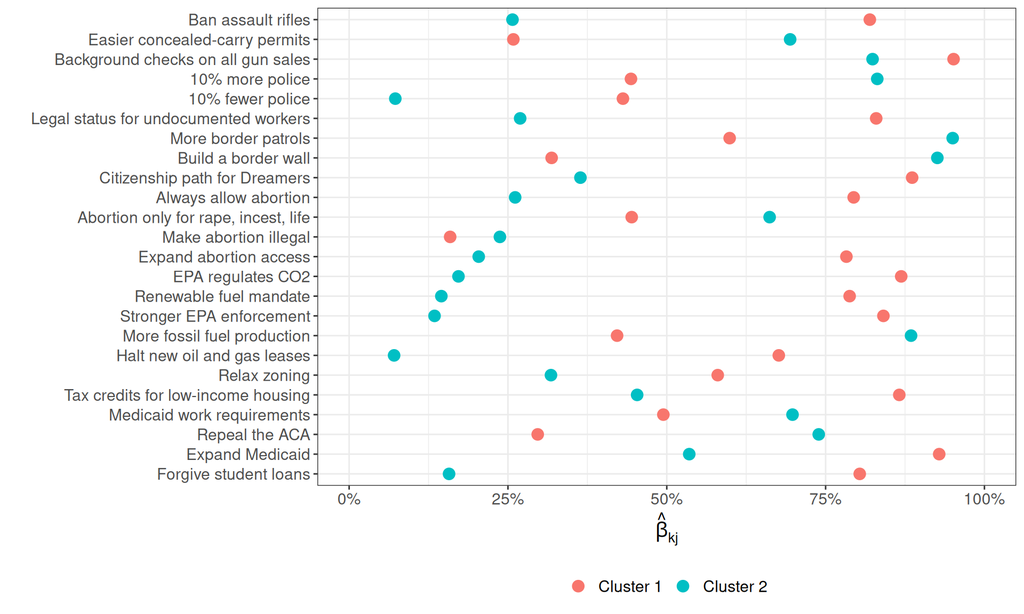

## Two clusters

- Cluster 2 (33%): conservative answers on almost everything. Cluster 1 (67%): liberal on most questions
  - Some questions split the clusters much less than others: 82% of cluster 2 support background checks; 44% of cluster 1 support more police
- Almost the same split as K-means

```r
table(kmeans = km2$cluster, mixture = apply(bmm2$gamma, 1, which.max))
```

```
      mixture
kmeans     1     2
     1   698  8105
     2 15650     0
```

- It lines up mostly with Party ID – 33% of Republicans land in “liberal” cluster 1

```r
round(prop.table(table(party = ces$pid3, cluster = apply(bmm2$gamma, 1, which.max)), 1), 2)
```

```
             cluster
party            1    2
  Democrat    0.95 0.05
  Independent 0.62 0.38
  Not sure    0.81 0.19
  Other       0.53 0.47
  Republican  0.33 0.67
```

## Two clusters

- Each respondent has a **probability** of belonging to each cluster

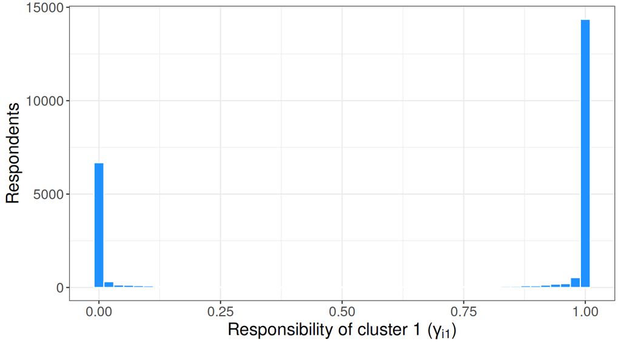

- 86% of respondents are assigned to a cluster with more than 99% probability
  - Under local independence, 24 answers are 24 **independent** pieces of evidence about $z_i$, so the posterior piles up near $0$ and $1$

## Five clusters

- Let’s add more clusters. With $K = 5$, the log posterior (up to a constant) across 10 random starts:

```r
set.seed(60637)
fits5 <- map(1:10, function(r) bmm_em(Y, K = 5))
map_dbl(fits5, "log_post")
```

```
 [1] -296879 -296879 -296879 -296879 -296978 -296879 -296879 -296879 -296879
[10] -296879
```

```r
bmm5 <- order_clusters(fits5[[which.max(map_dbl(fits5, "log_post"))]])
```

- Different starts get stuck at different local maxima - so be sure to use multiple runs!
- **Label switching**: runs that reach the same maximum may number the clusters differently. Permuting the labels doesn’t change the likelihood.

## Five clusters

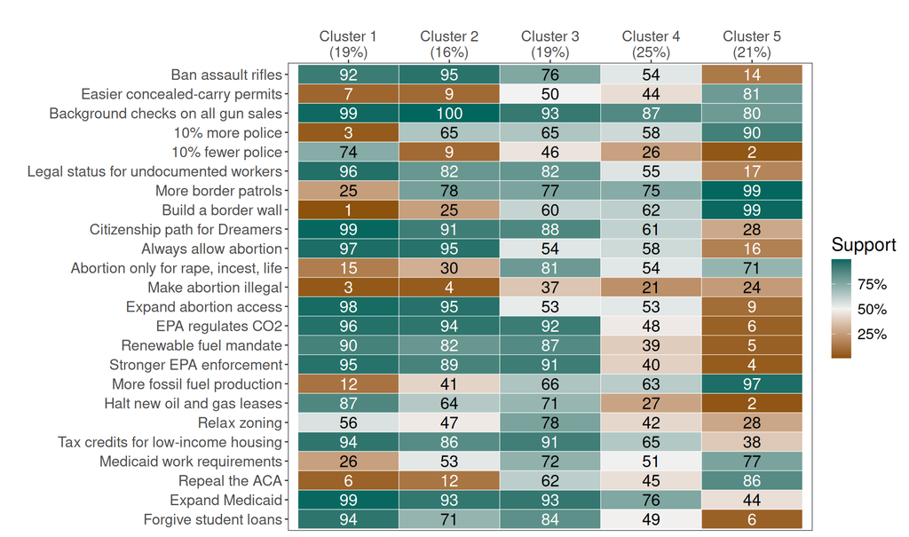

## Five clusters

- **Cluster 1**: Consistent liberals
- **Cluster 5**: Consistent conservatives
- **Cluster 2**: Liberal, except on **police and the border**
- **Cluster 4**: Probabilities between 30% and 70% on most questions
  - Seems like a cluster that has ideologically *unconstrained* preferences (Converse 1964)
- **Cluster 3**: A majority supports 22 of the 24 proposals – including **both** sides of the same question
  - 65% support more police and 46% support fewer; 93% support expanding Medicaid and 62% support repealing the ACA
  - Looks like **acquiescence** bias - a tendency to say “support” regardless of the content

## Five clusters

- Who is in each cluster?

```r
hard5 <- apply(bmm5$gamma, 1, which.max)
round(prop.table(table(cluster = hard5, ideology = ces$ideo5), 1), 2)[, c("Very liberal", "Liberal", "Moderate",
                                                                         "Conservative", "Very conservative", "Not sure")]
```

```
       ideology
cluster Very liberal Liberal Moderate Conservative Very conservative Not sure
      1         0.39    0.36     0.18         0.01              0.00     0.05
      2         0.10    0.29     0.46         0.06              0.01     0.07
      3         0.07    0.14     0.44         0.16              0.08     0.11
      4         0.03    0.09     0.40         0.23              0.09     0.16
      5         0.00    0.01     0.17         0.44              0.36     0.02
```

- The middle clusters (2-4) have the most self-described moderates; cluster 4 has the largest share of “Not sure”

## Five clusters

- The CES has survey weights. We can estimate each cluster’s prevalence in the **population** by weighting the responsibilities with these weights (`commonweight`)

```r
rbind(unweighted = colMeans(bmm5$gamma),
      weighted = colSums(ces$commonweight * bmm5$gamma) / sum(ces$commonweight))
```

```
            [,1]  [,2]  [,3]  [,4]  [,5]
unweighted 0.189 0.159 0.193 0.246 0.213
weighted   0.186 0.152 0.194 0.264 0.204
```

- One interesting feature is that the low-structure cluster 4 is under-represented in the raw sample

## Challenges with mixture models

- **Highly model dependent** - the clusters we find depend on the distribution we assume for $Y_i$ given $z_i$
  - Local independence is a substantial assumption: all of the correlation between answers has to be explained by the clusters
  - But some questions are logically dependent on others even conditional on ideology (e.g. abortion, policing).
- **Multi-modality** - Mixture model likelihoods often have multiple modes and EM is only guaranteed to converge to a **local** optimum
  - Can get stuck in a “bad” EM run (**Solution**: Run EM from multiple starting values and pick the one with the best log-likelihood (or log posterior))
  - **“Label-switching” problem**: Permuting the labels doesn’t change the likelihood
- **Challenges with Bayes** - Sampling-based inference can be tricky with mixtures due to the label-switching problem.
  - Different chains (or the same chain) can visit different permutations of the labels, so averaging $\beta_{1j}$ across draws will mix clusters together
  - Common to use an approximation to the posterior around the mode obtained via EM.

## Mixture models in Stan

- Stan can’t sample discrete parameters like $z_i$ (no gradient)
- But we can **marginalize out** the $z_i$. Same model and priors as our EM: Beta(2, 2) on each $\beta_{kj}$, flat on $\pi$

```r
bmm_stan_code <- "
data {
  int N; int J; int K;
  matrix[N, J] Y; // 1 = Support, 0 = Oppose
}
parameters {
  simplex[K] pi; // cluster prevalences (flat prior by default)
  matrix<lower=0, upper=1>[J, K] beta; // response probabilities
}
model {
  matrix[N, K] lp = Y * log(beta) + (1 - Y) * log1m(beta); // log f(Y_i | z_i = k), as in bmm_complete_loglik
  to_vector(beta) ~ beta(2, 2);
  for (i in 1:N) target += log_sum_exp(log(pi) + lp[i]'); // log of the sum over clusters
}
"
```

## Mixture models in Stan

- Fit $K = 5$ (this takes a few minutes – the likelihood sums over all 24,453 respondents at every step)

```r
bmm_stan_fit <- stan(
  model_code = bmm_stan_code,  # Stan code
  data = list(N = nrow(Y), J = ncol(Y), K = 5, Y = Y), # named list of data
  chains = 4,             # number of Markov chains
  warmup = 500,           # number of warmup iterations per chain
  iter = 1000,            # total number of iterations per chain
  cores = 4,              # number of cores
  refresh = 0,            # no progress shown
  seed = 53706            # random seed
  )
```

- **Label switching**: each chain’s posterior mean of $\pi$. The chains found the same clusters, but numbered them differently

```r
round(get_posterior_mean(bmm_stan_fit, pars = "pi")[, 1:4], 2)
```

```
      mean-chain:1 mean-chain:2 mean-chain:3 mean-chain:4
pi[1]         0.28         0.17         0.17         0.15
pi[2]         0.18         0.23         0.18         0.17
pi[3]         0.17         0.18         0.22         0.18
pi[4]         0.15         0.15         0.28         0.23
pi[5]         0.23         0.28         0.15         0.28
```

## Stan vs. EM

- Relabel every draw the same way we ordered the EM clusters (by the share giving the liberal answer)

```r
relabel <- function(beta, pi){ # beta is J x K in Stan
  liberal_share <- colMeans(liberal_answer * beta + (1 - liberal_answer) * (1 - beta))
  o <- order(liberal_share, decreasing = T)
  list(beta = t(beta[, o]), pi = pi[o]) # K x J, like the EM estimates
}
relabel_draws <- function(fit){
  draws <- rstan::extract(fit)
  relabeled <- map(1:nrow(draws$pi), function(s) relabel(draws$beta[s, , ], draws$pi[s, ]))
  list(beta = simplify2array(map(relabeled, "beta")), # K x J x draws
       pi = simplify2array(map(relabeled, "pi")))     # K x draws
}
stan_random <- relabel_draws(bmm_stan_fit)
```

```r
bmm5_worst <- order_clusters(fits5[[which.min(map_dbl(fits5, "log_post"))]]) # the EM start that found a worse local maximum
rbind(`EM (best start)` = bmm5$pi, `EM (worst start)` = bmm5_worst$pi, `Stan (posterior mean)` = rowMeans(stan_random$pi))
```

```
                       [,1]  [,2]  [,3]  [,4]  [,5]
EM (best start)       0.189 0.159 0.193 0.246 0.213
EM (worst start)      0.276 0.179 0.149 0.172 0.224
Stan (posterior mean) 0.276 0.177 0.149 0.173 0.225
```

## Stan vs. EM

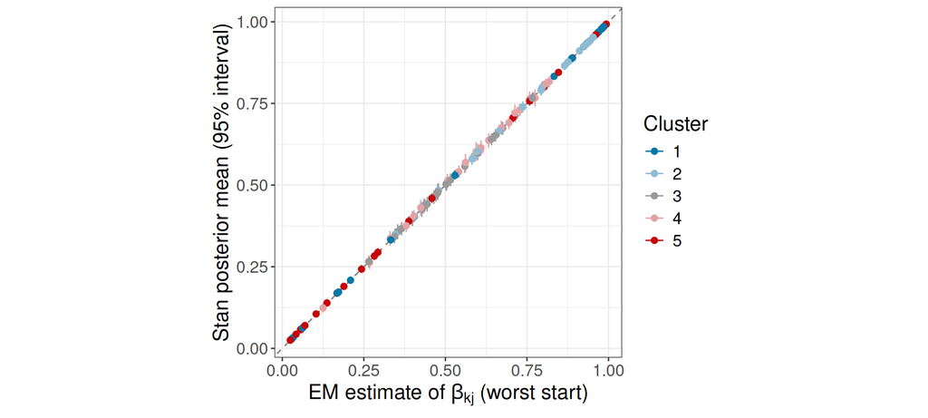

- All four chains align on the **worse** local maximum (log-likelihood -296,726 vs. -296,609)
- MCMC can’t jump between well-separated modes, so like EM, there’s no guarantee we’ve found the best mode.

## Starting Stan at the EM mode

- Solution: Find the mode with EM, then run MCMC for uncertainty

```r
em_init <- list(pi = bmm5$pi, beta = t(bmm5$beta)) # beta is J x K in Stan
bmm_stan_fit_em <- stan(
  model_code = bmm_stan_code, data = list(N = nrow(Y), J = ncol(Y), K = 5, Y = Y),
  chains = 4, warmup = 500, iter = 1000, cores = 4, refresh = 0, seed = 53706,
  init = rep(list(em_init), 4) # the same starting values for all four chains
  )
stan_em <- relabel_draws(bmm_stan_fit_em)
```

```r
rbind(`EM (best start)` = bmm5$pi, `Stan (started at EM)` = rowMeans(stan_em$pi))
```

```
                      [,1]  [,2]  [,3]  [,4]  [,5]
EM (best start)      0.189 0.159 0.193 0.246 0.213
Stan (started at EM) 0.188 0.159 0.194 0.245 0.213
```

- No label switching (every chain starts with the same labels) and we’ve guaranteed a good mode.

## Starting Stan at the EM mode

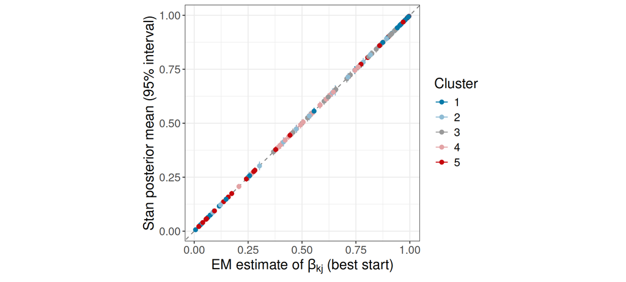

- Largest 95% interval width across the 120 $\beta_{kj}$: 0.048

## Choosing K

- Choosing $K$ is a problem of model comparison and selection.
  - Just like before, more parameters = better **in-sample** fit.
  - But we want to avoid **over-fitting**
- Just as last week, two approaches
  - **Information criteria** - Evaluate the in-sample log-likelihood at the maximum, penalized by some factor for the number of parameters
    - Here, $KJ + (K - 1)$ parameters
  - **Cross-validation** - Estimate the model on a **training set**. Compute the log-likelihood on a **held-out** test set.

## Choosing K

```r
set.seed(53703)
K_choice <- 1:10
fits_K <- map(K_choice, function(K) order_clusters(bmm_em_runs(Y, K, runs = 5)))
k_fit <- tibble(K = K_choice, log_lik = map_dbl(fits_K, "log_lik"), n_par = K * ncol(Y) + K - 1) %>%
  mutate(AIC = 2 * n_par - 2 * log_lik, BIC = log(nrow(Y)) * n_par - 2 * log_lik)
```

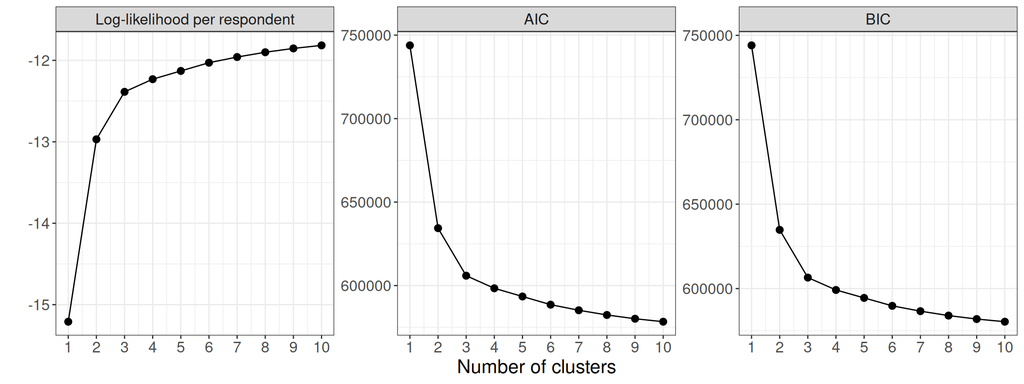

- Big gains up to $K = 3$, then smaller ones – but even **BIC** keeps improving through $K = 10$

## Choosing K

- 5-fold cross-validation: average held-out log-likelihood per respondent

```r
set.seed(60637)
n_folds <- 5
cv_fold <- sample(rep(1:n_folds, length.out = nrow(Y)))
heldout <- expand_grid(K = K_choice, fold = 1:n_folds) %>%
  mutate(ll = map2_dbl(K, fold, function(K, f){
    fold_fit <- bmm_em_runs(Y[cv_fold != f, ], K, runs = 3)
    bmm_loglik(Y[cv_fold == f, ], fold_fit$beta, fold_fit$pi) / sum(cv_fold == f)
  }))
```

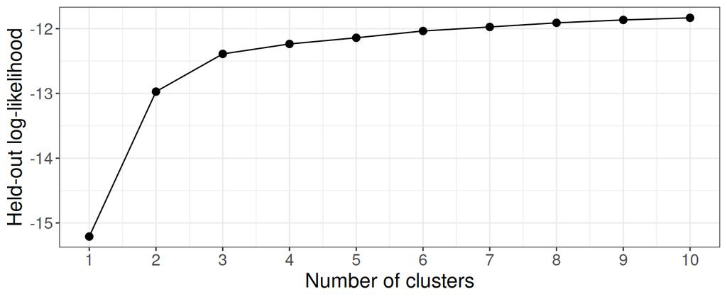

- With 24,453 respondents, more clusters keep predicting better out of sample. No obvious “right” $K$

## Checking local independence

- Under the mixture model, the implied covariance between questions is
  $$\text{Cov}(Y_{ij}, Y_{il}) = \sum_{k=1}^K \pi_k \beta_{kj}\beta_{kl} - p_j p_l$$
- Like a posterior predictive check, but plugging in the EM estimates: does the model reproduce the observed correlations among the various pairs of questions?

## Checking local independence

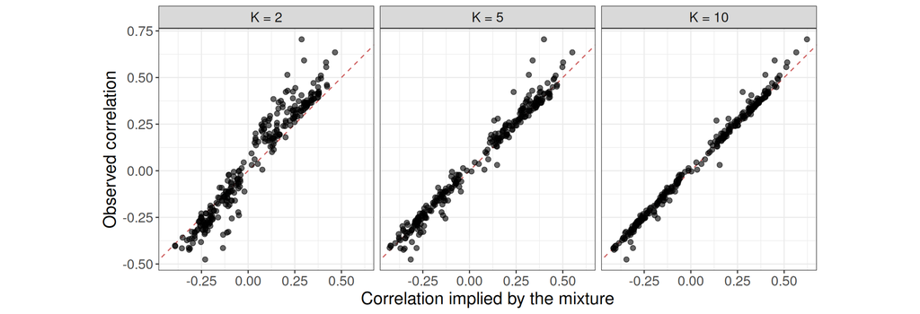

- With $K = 2$, the model **under-predicts** many of the positive correlations: answers are still correlated *within* clusters
  - Worst of all: always allowing abortion and expanding abortion access (observed correlation 0.7, implied 0.29)
  - Local independence is an implausible assumption - lots of overconfidence in the classification probabilities.
- Adding clusters soaks up some of that correlation.

## Logically exclusive questions

- A coherent respondent can’t support **both** 10% more police and 10% fewer police – these answers should be perfectly dependent

```r
table(more_police = ces$more_police, fewer_police = ces$fewer_police)
```

```
           fewer_police
more_police     0     1
          0  4869  5572
          1 11970  2042
```

- Yet 8% of respondents support both. Within each $K = 5$ cluster, the share supporting both:

| Cluster | Implied by local independence | Observed |
| --- | --- | --- |
| 1 | 3% | 2% |
| 2 | 6% | 3% |
| 3 | 30% | 25% |
| 4 | 15% | 10% |
| 5 | 2% | 1% |

- Local independence over-predicts “support both”, as it should – but interestingly the observed shares are nowhere near the $0\%$ that perfect dependence implies.

## Classifying the clusters

- Count the **liberal** answers each respondent gives (0-24) based on their “hard” cluster at $K = 5$

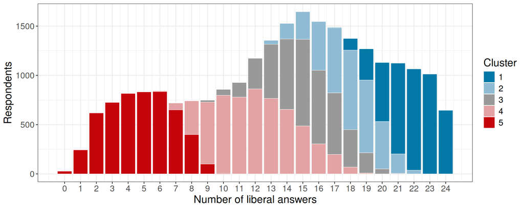

## Latent classes vs. latent traits

- **Mixture model** (“latent class”): a discrete $z_i$ for each respondent

  $$Pr(Y_{ij} = 1 | z_i = k) = \beta_{kj}$$
- **Item response theory** (“latent trait”): a continuous $\theta_i$ for each respondent, and a slope and intercept for each question

  $$Pr(Y_{ij} = 1 | \theta_i) = F(\alpha_j\theta_i - \tau_j)$$
- Both assume local independence conditional on the underlying latent variable
- But IRT uses a single **continuous** trait rather than a **discrete** classification.
- Maybe a single dimension works better here?
  - But it probably won’t do so well for cluster 4 (no structure) or cluster 3 (supporting both sides)
- Next week: fit IRT to the same 24 questions and see what we learn.

## Next week

- **Item response theory and ideal point models**
  - Latent trait models for binary responses
  - “Ideal point” models: inferring latent *continuous* preferences from discrete responses
  - Adding **temporal structure** through a random-walk prior.
- **Readings:** Clinton et al. (2004) and Imai et al. (2016)

## References

Broockman, David E., and Benjamin E. Lauderdale. 2025. “‘Moderates’.” *American Political Science Review*, ahead of print. https://doi.org/10.1017/S0003055424001333.

Clinton, Joshua, Simon Jackman, and Douglas Rivers. 2004. “The Statistical Analysis of Roll Call Data.” *American Political Science Review* 98 (2): 355–70. https://doi.org/10.1017/S0003055404001194.

Converse, Philip E. 1964. “The Nature of Belief Systems in Mass Publics.” In *Ideology and Discontent*, edited by David E. Apter. Free Press.

Dempster, Arthur P., Nan M. Laird, and Donald B. Rubin. 1977. “Maximum Likelihood from Incomplete Data via the EM Algorithm.” *Journal of the Royal Statistical Society: Series B (Methodological)* 39 (1): 1–38. https://doi.org/10.1111/j.2517-6161.1977.tb01600.x.

Fowler, Anthony, Seth J. Hill, Jeffrey B. Lewis, Chris Tausanovitch, Lynn Vavreck, and Christopher Warshaw. 2023. “Moderates.” *American Political Science Review* 117 (2): 643–60. https://doi.org/10.1017/S0003055422000818.

Imai, Kosuke, James Lo, and Jonathan Olmsted. 2016. “Fast Estimation of Ideal Points with Massive Data.” *American Political Science Review* 110 (4): 631–56. https://doi.org/10.1017/S000305541600037X.

Schaffner, Brian, Stephen Ansolabehere, Jeremy Pope, and Marissa Shih. 2024. *CES Common Content, 2023*. Harvard Dataverse. https://doi.org/10.7910/DVN/JQJTCC.